# Exploratory Analysis

### Introduction

We are interested in gathering statistics on video games for our final project. For most of the pandemic, video games were a way to escape and socialize with other players. They helped reduce stress and improve mental health during this time. Some related projects include an article posted by USA Today in 2021 and api based websites such as light.gg and lol.wiz that gathers statistics directly from games such as League of Legends and Destiny 2. We hope to answer questions about video game usage during the pandemic such as…

*“How has COVID changed video game sales and popularity?”*

*“How have video games impacted mental health during COVID?”*

*“How has COVID affected video game addiction?”*

### Part 1 - Summary Statistics

We decided to use the Games.csv dataset which consists of 175 observations. The most popular game was PlayerUnknown’s Battlegorund, selling 42 million copies after its release in December of 2017. The least popular games solid only 1 million.

### Part 2 - Aggregate Table

| Genre | Total |
| --- | --- |
| Action | 4 |
| Action-adventure | 6 |
| Action-adventure, platformer | 1 |
| Action-adventure, roguelike | 1 |
| Action-adventure, stealth | 1 |
| Action-adventure, Survival | 1 |
| Action role-playing | 12 |
| Action role-playing game | 1 |
| Action role-playing, hack and slash | 1 |
| Adventure | 2 |
| Adventure, puzzle | 1 |
| Amateur flight simulation | 1 |
| Battle royale | 2 |
| Beat ’em up, run-and-gun | 1 |
| Business simulation | 3 |
| City-building | 6 |
| City-building game | 3 |
| Compilation | 1 |
| Computer role-playing game | 1 |
| Construction and management simulation | 9 |
| Educational | 1 |
| Fighting | 3 |
| First-person shooter | 19 |
| God game | 3 |
| Grand strategy | 3 |
| Graphic adventure | 2 |
| Graphic adventure, puzzle | 1 |
| Interactive fiction | 1 |
| Interactive movie | 2 |
| Life simulation | 3 |
| Maze, arcade | 1 |
| Metroidvania | 1 |
| MMORPG | 6 |
| Platform | 1 |
| Point-and-click | 1 |
| Puzzle | 1 |
| Racing game | 1 |
| Rail shooter | 1 |
| Real-time strategy | 24 |
| Real-time strategy, grand strategy wargame | 1 |
| Real-time tactics | 1 |
| Role-playing game | 8 |
| RTS, 4X, Grand Strategy | 1 |
| Run and gun | 1 |
| Sandbox | 1 |
| Sandbox, survival | 1 |
| Sim racing | 1 |
| Simulation | 1 |
| Simulation, role-playing game | 1 |
| Space combat simulation | 1 |
| Sports | 1 |
| Survival | 5 |
| Survival horror | 1 |
| Tactical shooter | 3 |
| Third-person shooter | 1 |
| Third-person shooter, survival horror | 3 |
| Trivia game | 1 |
| Turn-based strategy | 1 |
| Turn-based strategy, 4X | 4 |
| Vehicle simulation | 2 |
| Visual novel, adventure | 2 |

This table takes the dataset from game.csv and takes the genre columns to group the games by genre. It displays the 61 different genres and summarizes the number of games under each. For example, if there were 5 games in the action genre, it would display in the **“Genre”** column *“Action”*, with the number *5* in the **“Total”** column next to it.

### Chart 1

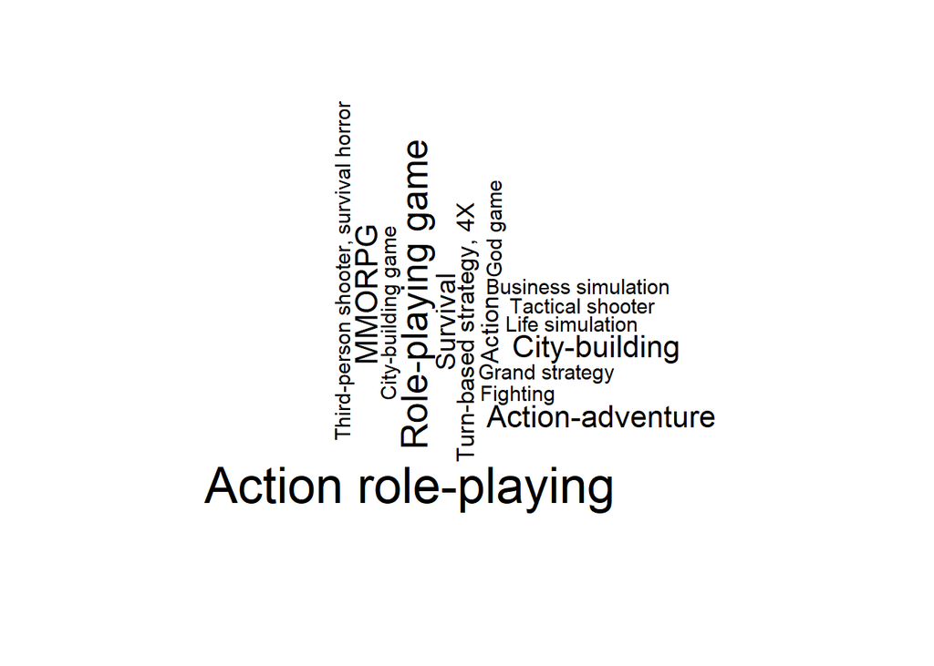